# 2_Avocados

Jeremy Whorton

1/29/2019

## Avocado Sales

In this lab we’re going to be looking at avocado prices! The dataset comes to us from kaggle and represents weekly retail scan data: avocado.csv. A description of the data can be found at the Hass Avocado Board website.

```r
library(tidyverse)
avo <- read.csv("https://www.dropbox.com/s/vsc1dkosz6nwake/avocado.csv?dl=1")
```

1. Which region sold the most bags of small organic avocados in 2017?

```r
avo %>%
  group_by(region) %>%
  filter(region != "TotalUS") %>%
  filter(type == "organic") %>%
  summarize(Small.Bags = sum(Small.Bags)) %>%
  top_n(1)
```

```
## # A tibble: 1 x 2
##   region    Small.Bags
##   <fctr>         <dbl>
## 1 Northeast    4232893
```

2. Use separate() to split the Date variable into year, month, and day. In which month is the highest volume of avocado sales?

```r
avo %>%
  separate(Date, sep = "-", into = c("Year", "Month", "Day")) %>%
  group_by(Month) %>%
  summarize(Total.Volume = sum(Total.Volume)) %>%
  top_n(1)
```

```
## # A tibble: 1 x 2
##   Month Total.Volume
##   <chr>        <dbl>
## 1 01       641550323
```

3. Which regions sell the most avocados by volume? Plot side-by-side boxplots of Total Volume for only the 5 regions with the highest averages for the Total Volume variable.

```r
top_regions <- avo %>%
  group_by(region) %>%
  filter(region != "TotalUS") %>%
  summarize(Total.Volume = sum(Total.Volume)) %>%
  top_n(5)
```

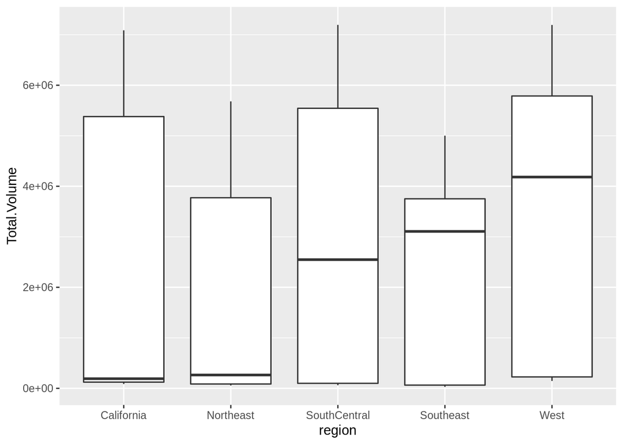

```r
avo %>%
  filter(region == top_regions$region) %>%
  ggplot(aes(x = region, y = Total.Volume)) + geom_boxplot()
```

4. In which regions is the price of organic versus conventional avocados most different? Support your answer with a few summary numbers and a plot.

```r
regional_types <- avo %>%
  group_by(region, type) %>%
  summarize(AveragePrice = mean(AveragePrice))

regional_types %>%
  mutate(difference = AveragePrice - lag(AveragePrice)) %>%
  na.omit() %>%
  summarize(difference = max(difference)) %>%
  top_n(5)
```

```
## # A tibble: 5 x 2
##   region              difference
##   <fctr>                   <dbl>
## 1 HartfordSpringfield      0.828
## 2 LasVegas                 0.696
## 3 PhoenixTucson            1.01
## 4 SanFrancisco             0.850
## 5 WestTexNewMexico         0.903
```

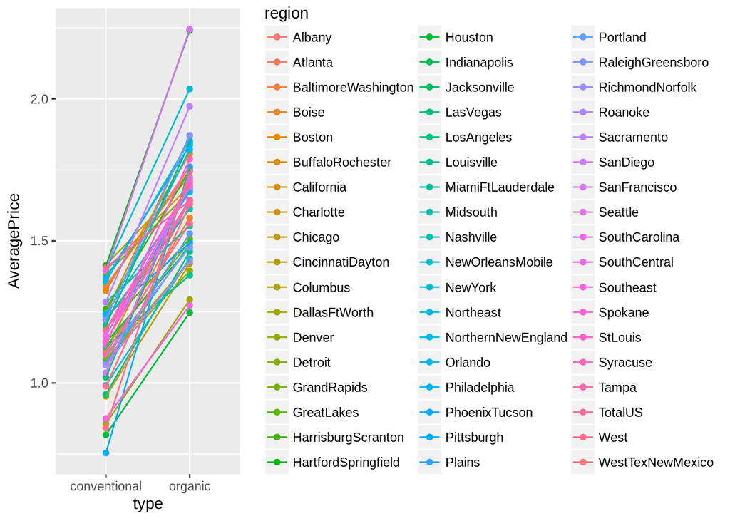

```r
regional_types %>%
  ggplot(aes(x = type, y = AveragePrice, color = region, group = region)) + geom_point() + geom_line()
```

In the graph, the lines with the steepest slope have the highest differences between conventional and organic prices.

5. How do their avocado habits differ? Make a plot that shows, for all 4 California regions, the percent of avocado sales that are small, large, or extra large. Separate your plot by conventional vs. organic avocados.

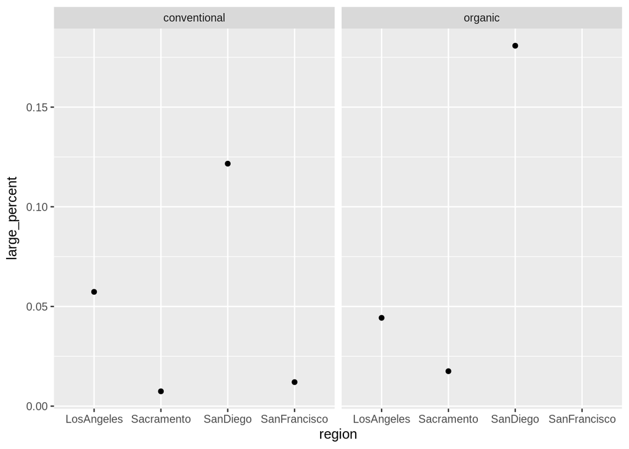

```r
habits <- avo %>%
  filter(region == "LosAngeles" | region == "Sacramento" | region == "SanDiego" | region == "SanFrancisco") %>%
  group_by(region, type) %>%
  mutate(large_percent = Large.Bags / Total.Bags,
         medium_percent = Small.Bags / Total.Bags,
         xlarge_percent = XLarge.Bags / Total.Bags)

habits %>%
  summarize(large_percent = mean(large_percent)) %>%
  ggplot(aes(x = region, y = large_percent)) + geom_point() + facet_grid(. ~ type)
```

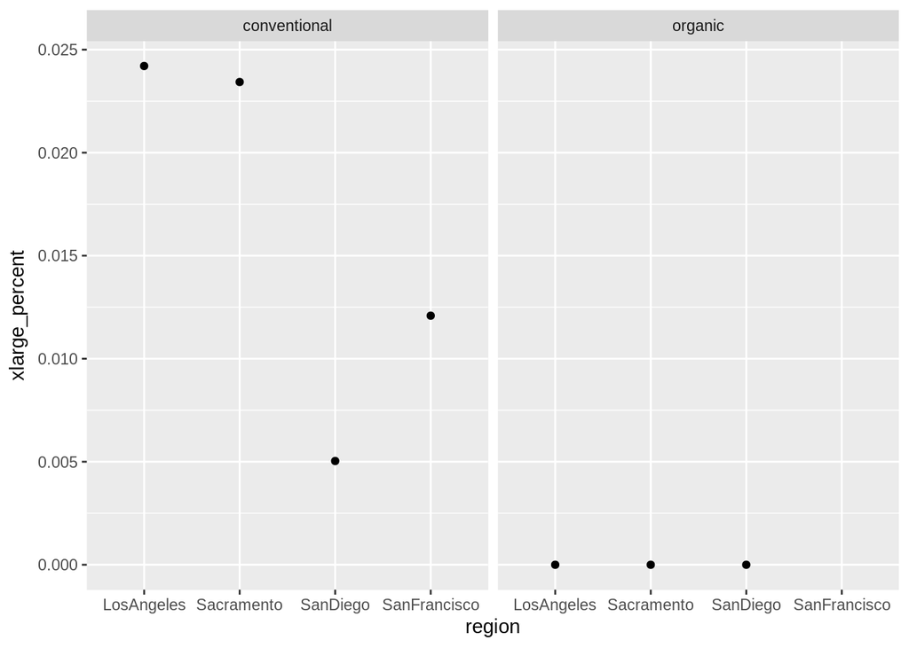

```r
habits %>%
  summarize(xlarge_percent = mean(xlarge_percent)) %>%
  ggplot(aes(x = region, y = xlarge_percent)) + geom_point() + facet_grid(. ~ type)
```

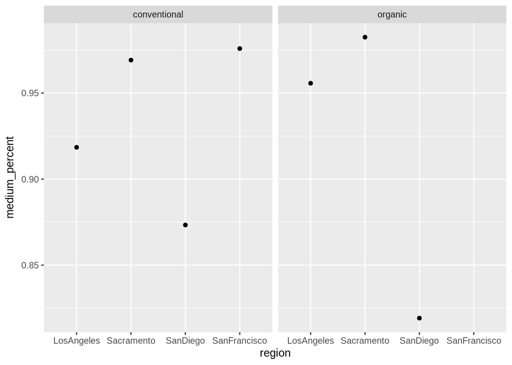

```r
habits %>%
  summarize(medium_percent = mean(medium_percent)) %>%
  ggplot(aes(x = region, y = medium_percent)) + geom_point() + facet_grid(. ~ type)
```